# FigureYa299pancanSurv

**Author(s)**: Xiaofan Lu; Yasi Zhang  
**Reviewer(s)**: Ying Ge  
**Date**: 2025-05-20

# 需求描述

# Demand description

想众筹下这张图，泛癌预后KM+Cox分析后，热图形式展示，最后再单独展示OS结果，内容看起来更立体丰富一点。

We want to crowdfund this figure - After pan-cancer prognostic KM + Cox analysis, display results in heatmap format, then separately showcase OS outcomes to make the content more three-dimensional and enriched.

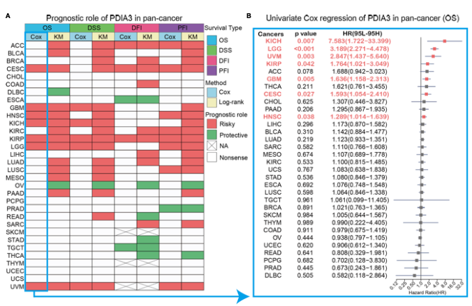

出自：https://www.frontiersin.org/articles/10.3389/fonc.2021.665870/full

图3 | (A) 基于单变量Cox回归和Kaplan-Meier模型，展示PDIA3表达与总生存期（OS）、疾病特异性生存期（DSS）、无病生存期（DFI）和无进展生存期（PFI）相关性的汇总结果。红色标注表示PDIA3是影响癌症患者预后的风险因素，绿色代表保护性因素。仅显示p值<0.05的显著性结果。 (B) 森林图通过单变量Cox回归方法展示PDIA3在各类癌症中的预后作用。红色标注的癌症类型表示PDIA3作为具有统计学意义的危险因素。

Source: https://www.frontiersin.org/articles/10.3389/fonc.2021.665870/full

FIGURE 3 | (A) Summary of the correlation between expression of PDIA3 with overall survival (OS), disease-specific survival (DSS), disease-free interval (DFI) and progression-free interval (PFI) based on the univariate Cox regression and Kaplan-Meier models. Red indicates that PDIA3 is a risk factor affecting the prognosis of cancer patients, and green represents a protective factor. Only p values < 0.05 are shown. (B) The forest plot exhibited the prognostic role of PDIA3 in cancers by univariate Cox regression method. The cancer type in red represents the PDIA3 acts as a risky factor with statistical significance.

# 应用场景

# Application scenarios

在泛癌中根据某感兴趣基因的表达计算该表达与预后的相关性；绘制预后热图。

更多泛癌FigureYa看这里https://k.youshop10.com/C8RkTgR3

In pan-cancer analysis, calculate the correlation between the expression of a gene of interest and prognosis based on its expression; plot a prognostic heatmap.

For more pan-cancer FigureYa, check herehttps://k.youshop10.com/C8RkTgR3

# 环境设置

# Environment Setup

使用国内镜像安装包。

Using domestic mirrors for package installation.

```r
options("repos"= c(CRAN="https://mirrors.tuna.tsinghua.edu.cn/CRAN/"))
options(BioC_mirror="http://mirrors.tuna.tsinghua.edu.cn/bioconductor/")
```

# 加载包

# Loading packages

```r
library(ggplot2)
library(data.table)
library(survival)
library(ComplexHeatmap)
library(forestplot)
library(survminer)
library(circlize)
# 显示英文报错信息
# Show English error messages
Sys.setenv(LANGUAGE = "en")

# 禁止chr转成factor
# Prevent character-to-factor conversion
options(stringsAsFactors = FALSE)
```

# 输入文件

# Input Files

跟FigureYa291PancanProgSigaturehttps://k.youshop10.com/OH-gnWgI的输入文件相同，不用重复下载。

merged_sample_quality_annotations.tsv，肿瘤注释文件。下载自https://gdc.cancer.gov/about-data/publications/pancanatlas，下载地址http://api.gdc.cancer.gov/data/1a7d7be8-675d-4e60-a105-19d4121bdebf。

EBPlusPlusAdjustPANCAN_IlluminaHiSeq_RNASeqV2.geneExp.tsv，表达矩阵，第一列是基因，之后是其在每个样本中的表达量。下载自http://api.gdc.cancer.gov/data/3586c0da-64d0-4b74-a449-5ff4d9136611。

Survival_SupplementalTable_S1_20171025_xena_sp，生存数据。来自https://xenabrowser.net/datapages/?dataset=Survival_SupplementalTable_S1_20171025_xena_sp&host=https%3A%2F%2Fpancanatlas.xenahubs.net&removeHub=https%3A%2F%2Fxena.treehouse.gi.ucsc.edu%3A443。

The input files are the same as those for FigureYa291PancanProgSignature https://k.youshop10.com/OH-gnWgI, so there is no need to download them again.

merged_sample_quality_annotations.tsv: Tumor annotation file. Downloaded from https://gdc.cancer.gov/about-data/publications/pancanatlas, direct download link: http://api.gdc.cancer.gov/data/1a7d7be8-675d-4e60-a105-19d4121bdebf.

EBPlusPlusAdjustPANCAN_IlluminaHiSeq_RNASeqV2.geneExp.tsv: Expression matrix, where the first column contains gene names and subsequent columns show expression levels in each sample. Downloaded fromhttp://api.gdc.cancer.gov/data/3586c0da-64d0-4b74-a449-5ff4d9136611.

Survival_SupplementalTable_S1_20171025_xena_sp: Survival data. Source: https://xenabrowser.net/datapages/?dataset=Survival_SupplementalTable_S1_20171025_xena_sp&host=https%3A%2F%2Fpancanatlas.xenahubs.net&removeHub=https%3A%2F%2Fxena.treehouse.gi.ucsc.edu%3A443.

```r
# 读取肿瘤注释文件
# Read tumor annotation file
rawAnno <- read.delim("merged_sample_quality_annotations.tsv",sep = "\t",row.names = NULL,check.names = F,stringsAsFactors = F,header = T)
rawAnno$simple_barcode <- substr(rawAnno$aliquot_barcode,1,15)
samAnno <- rawAnno[!duplicated(rawAnno$simple_barcode),c("cancer type", "simple_barcode")]
samAnno <- samAnno[which(samAnno$`cancer type` != ""),]
write.table(samAnno,"output_simple_sample_annotation.txt",sep = "\t",row.names = F,col.names = T,quote = F)

# 读取生存数据
# Read survival data
surv <- read.delim("Survival_SupplementalTable_S1_20171025_xena_sp", sep = "\t",row.names = 1,check.names = F,stringsAsFactors = F,header = T)

# 快速读取表达谱数据并做数据预处理
# Quickly read expression matrix and preprocess data
expr <- fread("EBPlusPlusAdjustPANCAN_IlluminaHiSeq_RNASeqV2.geneExp.tsv",sep = "\t",stringsAsFactors = F,check.names = F,header = T)
expr <- as.data.frame(expr); rownames(expr) <- expr[,1]; expr <- expr[,-1]
gene <- sapply(strsplit(rownames(expr),"|",fixed = T), "[",1)
expr$gene <- gene
expr <- expr[!duplicated(expr$gene),]
rownames(expr) <- expr$gene; expr <- expr[,-ncol(expr)]

# 对于这份泛癌数据，将略小于0的数值拉到0，否则不能取log（其他途径下载的泛癌数据可能不需要此操作）
# For this pan-cancer dataset, values slightly less than 0 should be adjusted to 0; otherwise, taking the logarithm is not possible (pan-cancer data downloaded from other sources may not require this operation).
expr[expr < 0] <- 0

colnames(expr) <- substr(colnames(expr),1,15)
gc()
```

```
##             used   (Mb) gc trigger   (Mb)  max used   (Mb)
## Ncells   3764191  201.1    7158984  382.4   4973300  265.7
## Vcells 235077123 1793.5  780846801 5957.4 780846801 5957.4
```

```r
# 设置感兴趣的基因
# Set gene of interest
geneOfInterest <- "PDIA3"
if(!is.element(geneOfInterest, rownames(expr))) {
  warning("The gene ", geneOfInterest," cannot be found!")
} else {
  message("The gene ", geneOfInterest," can be matched!")
}
```

```
## The gene PDIA3 can be matched!
```

```r
# 去掉对于感兴趣基因存在NA值的样本
# Remove samples with NA values for the gene of interest
expr.sub <- expr[geneOfInterest, ]
expr.sub <- as.data.frame(t(na.omit(t(expr.sub))))
keepSam <- colnames(expr.sub)
expr <- expr[geneOfInterest,keepSam]
rm(expr.sub); gc()
```

```
##           used  (Mb) gc trigger   (Mb)  max used   (Mb)
## Ncells 3765859 201.2    7158984  382.4   6409278  342.3
## Vcells 8134908  62.1  624677441 4766.0 780846801 5957.4
```

```r
# 确定肿瘤样本以及对应肿瘤类型
# Identify tumor samples and their cancer types
sam <- samAnno[which(samAnno$`cancer type` != "LAML"),"simple_barcode"]
comsam <- intersect(intersect(colnames(expr), sam), rownames(surv))
tumsam <- comsam[substr(comsam,14,14) == "0"]
tumAnno <- samAnno[which(samAnno$simple_barcode %in% tumsam),]
tumAnno <- tumAnno[order(tumAnno$`cancer type`),]
tumors <- unique(tumAnno$`cancer type`)

# 合并表达和生存数据
# Merge expression and survival data
exprSurv <- cbind.data.frame(expr = log2(as.numeric(expr[geneOfInterest,comsam]) + 1),
                             surv[comsam,c("OS","OS.time","DSS","DSS.time","DFI","DFI.time","PFI","PFI.time")])
write.table(exprSurv, "output_combined dataframe with both gene expression and survival information.txt",sep = "\t",row.names = T,col.names = NA,quote = F)
```

# 根据感兴趣基因的连续值进行单变量Cox模型计算风险

# Perform univariate Cox model analysis based on continuous values of genes of interest

```r
outTab.cox <- NULL
for(i in tumors) {
  sam <- tumAnno[which(tumAnno$`cancer type` == i),"simple_barcode"]
  exprSurvSub <- exprSurv[sam,]

  ## OS
  coxres <- summary(coxph(Surv(OS.time, OS) ~ expr, data = exprSurvSub))
  outTab.cox <- rbind.data.frame(outTab.cox,
                                 data.frame(tumor = i,
                                            event = "OS",
                                            beta = coxres$coefficients[1,1],
                                            hr = coxres$coefficients[1,2],
                                            lower = coxres$conf.int[1,3],
                                            upper = coxres$conf.int[1,4],
                                            p = coxres$coefficients[1,5],
                                            stringsAsFactors = F),
                                 stringsAsFactors = F)

  ## DSS
  coxres <- summary(coxph(Surv(DSS.time, DSS) ~ expr, data = exprSurvSub))
  outTab.cox <- rbind.data.frame(outTab.cox,
                                 data.frame(tumor = i,
                                            event = "DSS",
                                            beta = coxres$coefficients[1,1],
                                            hr = coxres$coefficients[1,2],
                                            lower = coxres$conf.int[1,3],
                                            upper = coxres$conf.int[1,4],
                                            p = coxres$coefficients[1,5],
                                            stringsAsFactors = F),
                                 stringsAsFactors = F)

  ## DFI
  if(i %in% c("SKCM","THYM","UVM","GBM")) {
    # 前三个肿瘤没有对应的DFI数据，GBM只有3个样本有对应的DFI，也去除（和原文不符）
    # The first three cancers lack DFI data, and GBM has only 3 samples with DFI (inconsistent with the original paper)
    outTab.cox <- rbind.data.frame(outTab.cox,
                                   data.frame(tumor = i,
                                              event = "DFI",
                                              beta = NA,
                                              hr = NA,
                                              lower = NA,
                                              upper = NA,
                                              p = NA,
                                              stringsAsFactors = F),
                                   stringsAsFactors = F)
  } else {
    coxres <- summary(coxph(Surv(DFI.time, DFI) ~ expr, data = exprSurvSub))
    outTab.cox <- rbind.data.frame(outTab.cox,
                                   data.frame(tumor = i,
                                              event = "DFI",
                                              beta = coxres$coefficients[1,1],
                                              hr = coxres$coefficients[1,2],
                                              lower = coxres$conf.int[1,3],
                                              upper = coxres$conf.int[1,4],
                                              p = coxres$coefficients[1,5],
                                              stringsAsFactors = F),
                                   stringsAsFactors = F)
  }

  ## PFI
  coxres <- summary(coxph(Surv(PFI.time, PFI) ~ expr, data = exprSurvSub))
  outTab.cox <- rbind.data.frame(outTab.cox,
                                 data.frame(tumor = i,
                                            event = "PFI",
                                            beta = coxres$coefficients[1,1],
                                            hr = coxres$coefficients[1,2],
                                            lower = coxres$conf.int[1,4],
                                            upper = coxres$conf.int[1,4],
                                            p = coxres$coefficients[1,5],
                                            stringsAsFactors = F),
                                 stringsAsFactors = F)
}
write.table(outTab.cox, file = "output_summary of cox result in pancancer.txt",sep = "\r",row.names = F,col.names = T,quote = F)
```

# 根据感兴趣基因的最佳cutoff做KM

# Perform KM analysis based on the optimal cutoff of genes of interest

有些肿瘤因为数据问题无法估计HR，不过不影响绘图。

Some tumors cannot estimate HR due to data issues, but this does not affect plotting.

```r
minprop <- 0.2
outTab.km <- NULL
for(i in tumors) {
  sam <- tumAnno[which(tumAnno$`cancer type` == i),"simple_barcode"]
  exprSurvSub <- exprSurv[sam,]

  ## OS
  bestcut <- surv_cutpoint(exprSurvSub,
                           time = "OS.time",
                           event = "OS",
                           variables = "expr",

                           #默认组内sample不能低于20%
                           # Minimum sample proportion per group set to 20%
                           minprop = minprop)

  cutoff <- bestcut$cutpoint[1,1]
  exprSurvSub$group <- factor(ifelse(exprSurvSub$expr > cutoff,"High","Low"), levels = c("Low","High"))
  fitd <- survdiff(Surv(OS.time, OS) ~ group, data=exprSurvSub, na.action=na.exclude)
  p.val <- 1 - pchisq(fitd$chisq, length(fitd$n) - 1)
  HR <- (fitd$obs[2]/fitd$exp[2])/(fitd$obs[1]/fitd$exp[1])
  outTab.km <- rbind.data.frame(outTab.km,
                                data.frame(tumor = i,
                                           event = "OS",
                                           hr = HR,
                                           lower = exp(log(HR) - qnorm(0.975)*sqrt(1/fitd$exp[2]+1/fitd$exp[1])),
                                           upper = exp(log(HR) + qnorm(0.975)*sqrt(1/fitd$exp[2]+1/fitd$exp[1])),
                                           p = p.val,
                                           stringsAsFactors = F),
                                stringsAsFactors = F)

  ## DSS
  bestcut <- surv_cutpoint(exprSurvSub,
                           time = "DSS.time",
                           event = "DSS",
                           variables = "expr",

                           #默认组内sample不能低于20%
                           # Minimum sample proportion per group set to 20%
                           minprop = minprop)

  cutoff <- bestcut$cutpoint[1,1]
  exprSurvSub$group <- factor(ifelse(exprSurvSub$expr > cutoff,"High","Low"), levels = c("High","Low"))
  fitd <- survdiff(Surv(DSS.time, DSS) ~ group, data=exprSurvSub, na.action=na.exclude)
  p.val <- 1 - pchisq(fitd$chisq, length(fitd$n) - 1)
  outTab.km <- rbind.data.frame(outTab.km,
                                data.frame(tumor = i,
                                           event = "DSS",
                                           hr = (fitd$obs[2]/fitd$exp[2])/(fitd$obs[1]/fitd$exp[1]),
                                           lower = exp(log(HR) - qnorm(0.975)*sqrt(1/fitd$exp[2]+1/fitd$exp[1])),
                                           upper = exp(log(HR) + qnorm(0.975)*sqrt(1/fitd$exp[2]+1/fitd$exp[1])),
                                           p = p.val,
                                           stringsAsFactors = F),
                                stringsAsFactors = F)

  ## DFI
  if(i %in% c("SKCM","THYM","UVM","GBM")) {
    # 前三个肿瘤没有对应的DFI数据，GBM只有3个样本有对应的DFI，也去除（和原文不符）
    # First three tumor types lack DFI data; GBM has only 3 samples with DFI (inconsistent with original paper)
    outTab.km <- rbind.data.frame(outTab.km,
                                  data.frame(tumor = i,
                                             event = "DFI",
                                             hr = NA,
                                             lower = NA,
                                             upper = NA,
                                             p = NA,
                                             stringsAsFactors = F),
                                  stringsAsFactors = F)
  } else {
    bestcut <- surv_cutpoint(exprSurvSub,
                             time = "DFI.time",
                             event = "DFI",
                             variables = "expr",

                             #默认组内sample不能低于20%
                             # Minimum sample proportion per group set to 20%
                             minprop = minprop)

    cutoff <- bestcut$cutpoint[1,1]
    exprSurvSub$group <- factor(ifelse(exprSurvSub$expr > cutoff,"High","Low"), levels = c("High","Low"))
    fitd <- survdiff(Surv(DFI.time, DFI) ~ group, data=exprSurvSub, na.action=na.exclude)
    p.val <- 1 - pchisq(fitd$chisq, length(fitd$n) - 1)
    outTab.km <- rbind.data.frame(outTab.km,
                                  data.frame(tumor = i,
                                             event = "DFI",
                                             hr = (fitd$obs[2]/fitd$exp[2])/(fitd$obs[1]/fitd$exp[1]),
                                             lower = exp(log(HR) - qnorm(0.975)*sqrt(1/fitd$exp[2]+1/fitd$exp[1])),
                                             upper = exp(log(HR) + qnorm(0.975)*sqrt(1/fitd$exp[2]+1/fitd$exp[1])),
                                             p = p.val,
                                             stringsAsFactors = F),
                                  stringsAsFactors = F)
  }

  ## PFI
  bestcut <- surv_cutpoint(exprSurvSub,
                           time = "PFI.time",
                           event = "PFI",
                           variables = "expr",

                           #默认组内sample不能低于20%
                           # Minimum sample proportion per group set to 20%
                           minprop = minprop)

  cutoff <- bestcut$cutpoint[1,1]
  exprSurvSub$group <- factor(ifelse(exprSurvSub$expr > cutoff,"High","Low"), levels = c("High","Low"))
  fitd <- survdiff(Surv(PFI.time, PFI) ~ group, data=exprSurvSub, na.action=na.exclude)
  p.val <- 1 - pchisq(fitd$chisq, length(fitd$n) - 1)
  outTab.km <- rbind.data.frame(outTab.km,
                                data.frame(tumor = i,
                                           event = "PFI",
                                           hr = (fitd$obs[2]/fitd$exp[2])/(fitd$obs[1]/fitd$exp[1]),
                                           lower = exp(log(HR) - qnorm(0.975)*sqrt(1/fitd$exp[2]+1/fitd$exp[1])),
                                           upper = exp(log(HR) + qnorm(0.975)*sqrt(1/fitd$exp[2]+1/fitd$exp[1])),
                                           p = p.val,
                                           stringsAsFactors = F),
                                stringsAsFactors = F)
}
write.table(outTab.km, file = "output_summary of km result in pancancer.txt",sep = "\r",row.names = F,col.names = T,quote = F)
```

# 开始画图

# Plotting

## 绘制热图

## Generate Heatmap

```r
# 设置颜色
# Set colors
blue   <- "#A0CEE3"
yellow <- "#EFEFBE"
sea    <- "#37BCDF"
green  <- "#71BC5D"
cherry <- "#E5588C"
red    <- "#E46A6B"
purple <- "#8959A3"

# 制作热图绘制数据
# Prepare heatmap data
hmInput <- NULL
for (i in tumors) {

  cox.res <- outTab.cox[which(outTab.cox$tumor == i),]
  km.res <- outTab.km[which(outTab.km$tumor == i),]

  cox.res$dirct <- ifelse(cox.res$hr > 1 & cox.res$p < 0.05, "Risky",
                          ifelse(cox.res$hr < 1 & cox.res$p < 0.05, "Protective","Nonsense"))
  km.res$dirct <- ifelse(km.res$hr > 1 & km.res$p < 0.05, "Risky",
                         ifelse(km.res$hr < 1 & km.res$p < 0.05, "Protective","Nonsense"))
  hmInput <- rbind.data.frame(hmInput,
                              data.frame(OS.cox = cox.res[1,"dirct"],
                                         OS.km = km.res[1,"dirct"],
                                         DSS.cox = cox.res[2,"dirct"],
                                         DSS.km = km.res[2,"dirct"],
                                         DFI.cox = cox.res[3,"dirct"],
                                         DFI.km = km.res[3,"dirct"],
                                         PFI.cox = cox.res[4,"dirct"],
                                         PFI.km = km.res[4,"dirct"],
                                         row.names = i,
                                         stringsAsFactors = F),
                              stringsAsFactors = F)
}
hmInput[is.na(hmInput)] <- "N/A"
write.table(hmInput, file = "output_summary of gene prognositicationin pancancer.txt",sep = "\t",row.names = T,col.names = NA,quote = F)

# 注意：结果在某些肿瘤上有较大出入，可能的原因有：
# 1. 泛癌表达谱使用不一致
# 2. 最佳生存曲线cutoff的minprop选择不一致
# 3. 对KM分析中HR的计算不一致，原作者可能依然采用Cox回归估计二分类下的HR
# Note: Results show significant discrepancies in some tumors, possible reasons:
# 1. Inconsistent pan-cancer expression profiles used
# 2. Different minprop selections for optimal survival curve cutoff
# 3. Inconsistent HR calculation in KM analysis - original authors might still use Cox regression to estimate HR for binary classification

# 修改热图数据
# Modify heatmap data
indata <- hmInput
# 为了使得risky出现在图例的顶部，所以设置一个最小值0
# Set to 0 to display "Risky" at top of legend
indata[indata == "Risky"] <- 0
# 根据原文，依次设置为1
# Set to 1 following original paper
indata[indata == "Protective"] <- 1
# 根据原文，依次设置为2
# Set to 2 following original paper
indata[indata == "N/A"] <- 2
# 根据原文，依次设置为3
# Set to 3 following original paper
indata[indata == "Nonsense"] <- 3

# 构建列注释
# Create column annotations
annCol <- data.frame("Method" = rep(c("Cox","Log-rank"),4),
                     "Survival Type" = rep(c("OS","DSS","DFI","PFI"), each = 2),
                     check.names = F,
                     row.names = colnames(indata))
annColors <- list("Method" = c("Cox" = blue, "Log-rank" = yellow),
                  "Survival Type" = c("OS" = sea, "DSS" = green, "DFI" = cherry, "PFI" = purple))
col_fun = circlize::colorRamp2(c(0, 1, 2, 3), c(red,green,"grey50","white"))

# 绘制热图
# Generate heatmap
hm <- Heatmap(matrix = as.matrix(indata),
              border = "black",
              rect_gp = gpar(col = "black"),
              name = "Prognostic role",
              cluster_rows = F,
              cluster_columns = F,
              col = c(red,green,"grey50","white"),
              show_row_names = T,
              show_column_names = F,
              row_names_side = "left",
              top_annotation = HeatmapAnnotation(df = annCol,
                                                 col = annColors,
                                                 gp = gpar(col = "black"),
                                                 border = TRUE),
              width = grid::unit(8, "cm"),
              height = grid::unit(15, "cm"),
              heatmap_legend_param = list(at = c(0, 1, 2, 3),
                                          legend_gp = grid::gpar(fill = col_fun(c(0,1,2,3))),
                                          labels = c("Risky", "Protective","N/A","Nonsense")))
pdf("prognostic heatmap.pdf", width = 10,height = 10)
draw(hm)
invisible(dev.off())
```

[figure not shown]

## 绘制基于OS的森林图

## Generate forest plot based on OS

```r
fpInput <- outTab.cox[which(outTab.cox$event == "OS"),]
hrtable <- fpInput[,c("tumor","event","beta","hr","lower","upper","p")]

tabletext <- cbind(c("Cancers",hrtable$tumor),
                   c("p value",ifelse(round(as.numeric(hrtable$p),3) < 0.001,"<0.001",round(as.numeric(hrtable$p),3))),
                   c("HR (95L-95H)",paste0(round(as.numeric(hrtable$hr),3), " (",
                                          round(as.numeric(hrtable$lower),3),"-",
                                          round(as.numeric(hrtable$upper),3),")")))

pdf("forestplot of os risk table in pancancer.pdf", width = 8, height = 8)
forestplot(labeltext=tabletext,
           mean=c(NA,as.numeric(hrtable$hr)),# HR
           lower=c(NA,as.numeric(hrtable$lower)),
           upper=c(NA,as.numeric(hrtable$upper)),
           graph.pos = 4,
           graphwidth = unit(.3,"npc"),
           fn.ci_norm="fpDrawDiamondCI",
           col=fpColors(box="grey50", lines="grey50", zero = "black"),
           boxsize=c(NA,ifelse(as.numeric(hrtable$p) < 0.05,0.8,0.4)),
           lwd.ci=1,
           ci.vertices.height = 0.1,ci.vertices=F,
           zero=1,
           lwd.zero=2,
           xticks = c(0,1,2,4,8,13),
           lwd.xaxis=2,
           xlab="Hazard ratio",
           hrzl_lines=list("1" = gpar(lwd=2, col="black"),
                           "34" = gpar(lwd=2, col="black")),
           txt_gp=fpTxtGp(label=gpar(cex=1),
                          ticks=gpar(cex=0.85),
                          xlab=gpar(cex=1),
                          title=gpar(cex=1.2)),
           lineheight = unit(.55,"cm"),
           colgap = unit(0.4,"cm"),
           mar=unit(rep(1.5, times = 4), "cm"),
           new_page = F
)
invisible(dev.off())
```

[figure not shown]

# 会话信息